# Project - TheraBank Personal Loan Campaign

# Objective:

The project objective is to predict the likelihood of a liability customer buying personal loans.

## Domain:

Banking

## Business Context:

This case is about Thera Bank whose management wants to explore ways of converting its liability customers to personal loan customers (while retaining them as depositors). A campaign that the bank ran last year for liability customers showed a healthy conversion rate of over 9% success. This has encouraged the retail marketing department to devise campaigns with better target marketing to increase the success ratio with a minimal budget.

## Learning Outcomes:

- Exploratory Data Analysis
- Preparing the data to train a model
- Training and making predictions using a classification model
- Model evaluation

## Attribute Information:

- ID: Customer ID
- Age: Customer's age in completed years
- Experience: #years of professional experience
- Income: Annual income of the customer.(in thousand of dollars)
- ZIP Code: Home Address ZIP code.
- Family: Family size of the customer
- CCAvg: Avg. spending on credit cards per month. (in thousand of dollars)
- Education: Education Level.
  - 1: Undergrad;
  - 2: Graduate;
  - 3: Advanced/Professional
- Mortgage: Value of house mortgage if any.(in thousand of dollars)
- Personal Loan: Did this customer accept the personal loan offered in the last campaign?
- Securities Account: Does the customer have a securities account with the bank?
- CD Account: Does the customer have a certificate of deposit (CD) account with the bank?
- Online: Does the customer use internet banking facilities?
- Credit card: Does the customer use a credit card issued by the bank?

### Question 1: Import the datasets and libraries, check datatype, statistical summary, shape, null values or incorrect imputation. (5 marks)

### Import the Libraries

```python
import warnings
warnings.filterwarnings('ignore')
```

```python
import pandas as pd
import numpy as np
import seaborn as sns
import matplotlib.pyplot as plt
import statsmodels.api as sm
from sklearn.model_selection import train_test_split
from sklearn.linear_model import LogisticRegression
from sklearn.metrics import mean_squared_error
from sklearn import metrics
from sklearn.metrics import classification_report, confusion_matrix
```

### Import the dataset

```python
df = pd.read_csv('Bank_Personal_Loan_Modelling.csv')
```

```python
df.head()
```

|  | ID | Age | Experience | Income | ZIP Code | Family | CCAvg | Education | Mortgage | Personal Loan | Securities Account | CD Account | Online | CreditCard |
| --- | --- | --- | --- | --- | --- | --- | --- | --- | --- | --- | --- | --- | --- | --- |
| 0 | 1 | 25 | 1 | 49 | 91107 | 4 | 1.6 | 1 | 0 | 0 | 1 | 0 | 0 | 0 |
| 1 | 2 | 45 | 19 | 34 | 90089 | 3 | 1.5 | 1 | 0 | 0 | 1 | 0 | 0 | 0 |
| 2 | 3 | 39 | 15 | 11 | 94720 | 1 | 1.0 | 1 | 0 | 0 | 0 | 0 | 0 | 0 |
| 3 | 4 | 35 | 9 | 100 | 94112 | 1 | 2.7 | 2 | 0 | 0 | 0 | 0 | 0 | 0 |
| 4 | 5 | 35 | 8 | 45 | 91330 | 4 | 1.0 | 2 | 0 | 0 | 0 | 0 | 0 | 1 |

```python
#Check datatype
df.info()

#The output below shows that data types of 2 types namely float64 and int64.There were no objects or Strings data types
```

```
<class 'pandas.core.frame.DataFrame'>
RangeIndex: 5000 entries, 0 to 4999
Data columns (total 14 columns):
 #   Column              Non-Null Count  Dtype
---  ------              --------------  -----
 0   ID                  5000 non-null   int64
 1   Age                 5000 non-null   int64
 2   Experience          5000 non-null   int64
 3   Income              5000 non-null   int64
 4   ZIP Code            5000 non-null   int64
 5   Family              5000 non-null   int64
 6   CCAvg               5000 non-null   float64
 7   Education           5000 non-null   int64
 8   Mortgage            5000 non-null   int64
 9   Personal Loan       5000 non-null   int64
 10  Securities Account  5000 non-null   int64
 11  CD Account          5000 non-null   int64
 12  Online              5000 non-null   int64
 13  CreditCard          5000 non-null   int64
dtypes: float64(1), int64(13)
memory usage: 547.0 KB
```

```python
#Statistical summary
df.describe().T

# One observation is that column Experience includes negative value. This has to be addressed later
# Age  has mean= median , uniformly distributed and no skew
# Experience has mean = median and uniformly distributed. zero skew
# Experience and Age have very similar attributes
# Zip code has a narrow range with relatively little variation but slightly left-skewed
# Income is right or positively skewed with mean > median.
```

|  | count | mean | std | min | 25% | 50% | 75% | max |
| --- | --- | --- | --- | --- | --- | --- | --- | --- |
| ID | 5000.0 | 2500.500000 | 1443.520003 | 1.0 | 1250.75 | 2500.5 | 3750.25 | 5000.0 |
| Age | 5000.0 | 45.338400 | 11.463166 | 23.0 | 35.00 | 45.0 | 55.00 | 67.0 |
| Experience | 5000.0 | 20.104600 | 11.467954 | -3.0 | 10.00 | 20.0 | 30.00 | 43.0 |
| Income | 5000.0 | 73.774200 | 46.033729 | 8.0 | 39.00 | 64.0 | 98.00 | 224.0 |
| ZIP Code | 5000.0 | 93152.503000 | 2121.852197 | 9307.0 | 91911.00 | 93437.0 | 94608.00 | 96651.0 |
| Family | 5000.0 | 2.396400 | 1.147663 | 1.0 | 1.00 | 2.0 | 3.00 | 4.0 |
| CCAvg | 5000.0 | 1.937938 | 1.747659 | 0.0 | 0.70 | 1.5 | 2.50 | 10.0 |
| Education | 5000.0 | 1.881000 | 0.839869 | 1.0 | 1.00 | 2.0 | 3.00 | 3.0 |
| Mortgage | 5000.0 | 56.498800 | 101.713802 | 0.0 | 0.00 | 0.0 | 101.00 | 635.0 |
| Personal Loan | 5000.0 | 0.096000 | 0.294621 | 0.0 | 0.00 | 0.0 | 0.00 | 1.0 |
| Securities Account | 5000.0 | 0.104400 | 0.305809 | 0.0 | 0.00 | 0.0 | 0.00 | 1.0 |
| CD Account | 5000.0 | 0.060400 | 0.238250 | 0.0 | 0.00 | 0.0 | 0.00 | 1.0 |
| Online | 5000.0 | 0.596800 | 0.490589 | 0.0 | 0.00 | 1.0 | 1.00 | 1.0 |
| CreditCard | 5000.0 | 0.294000 | 0.455637 | 0.0 | 0.00 | 0.0 | 1.00 | 1.0 |

```python
#Shape of the dataset
df.shape

# 5000 rows and 14 columns in Data set
```

```
(5000, 14)
```

```python
#Check for null values or incorrect imputation
df.isna().sum()

# There are no null values in the Dataset
```

```
ID                    0
Age                   0
Experience            0
Income                0
ZIP Code              0
Family                0
CCAvg                 0
Education             0
Mortgage              0
Personal Loan         0
Securities Account    0
CD Account            0
Online                0
CreditCard            0
dtype: int64
```

```python
# Check if any missing value
df.isnull().any()
```

```
ID                    False
Age                   False
Experience            False
Income                False
ZIP Code              False
Family                False
CCAvg                 False
Education             False
Mortgage              False
Personal Loan         False
Securities Account    False
CD Account            False
Online                False
CreditCard            False
dtype: bool
```

### Question 2: Study the data distribution in each attribute, and target variable, share your findings. (20 marks)

- Number of unique in each column?
- Number of people with zero mortgage?
- Number of people with zero credit card spending per month?
- Value counts of all categorical columns.
- Univariate and Bivariate
- Get data model ready

```python
#Number of unique in each column?
for col in df:
    print(col)
    print("nos of unique", df[col].nunique())
    print("")

# there are 5000 uniques in ID.
```

```
ID
nos of unique 5000

Age
nos of unique 45

Experience
nos of unique 47

Income
nos of unique 162

ZIP Code
nos of unique 467

Family
nos of unique 4

CCAvg
nos of unique 108

Education
nos of unique 3

Mortgage
nos of unique 347

Personal Loan
nos of unique 2

Securities Account
nos of unique 2

CD Account
nos of unique 2

Online
nos of unique 2

CreditCard
nos of unique 2
```

```python
#Number of people with zero mortgage?
df.loc[df.Mortgage==0,['ID']]

#There are 3462 people with zero mortgage
```

|  | ID |
| --- | --- |
| 0 | 1 |
| 1 | 2 |
| 2 | 3 |
| 3 | 4 |
| 4 | 5 |
| ... | ... |
| 4994 | 4995 |
| 4995 | 4996 |
| 4997 | 4998 |
| 4998 | 4999 |
| 4999 | 5000 |

3462 rows × 1 columns

```python
#Number of people with zero credit card spending per month?
df.loc[df.CCAvg==0,['ID']]

#There are 106 people with zero credit card spending per month
```

|  | ID |
| --- | --- |
| 63 | 64 |
| 128 | 129 |
| 198 | 199 |
| 210 | 211 |
| 215 | 216 |
| ... | ... |
| 4801 | 4802 |
| 4826 | 4827 |
| 4837 | 4838 |
| 4910 | 4911 |
| 4949 | 4950 |

106 rows × 1 columns

### Value counts of all categorical columns

##### From datatype check in question 1,we did not observe any categorical columns. However some of the columns are Yes/No type columns before they were encoded as ordinal. Also column 'Education' was also encoded as ordinal. Therefore we consider these columns for value count as given in the following

```python
df['Education'].value_counts()
```

```
1    2096
3    1501
2    1403
Name: Education, dtype: int64
```

```python
df['CD Account'].value_counts()

# a majority of people do not have a CD account with the Bank
```

```
0    4698
1     302
Name: CD Account, dtype: int64
```

```python
df['Online'].value_counts()
```

```
1    2984
0    2016
Name: Online, dtype: int64
```

```python
df['CreditCard'].value_counts()
```

```
0    3530
1    1470
Name: CreditCard, dtype: int64
```

```python
df['Securities Account'].value_counts()

# a majority of people do not have a securities account with the Bank
```

```
0    4478
1     522
Name: Securities Account, dtype: int64
```

```python
df['Family'].value_counts()
```

```
1    1472
2    1296
4    1222
3    1010
Name: Family, dtype: int64
```

```python
df['Personal Loan'].value_counts()

# a majoriy of people did not take a personal loan with the bank during the last campaign
```

```
0    4520
1     480
Name: Personal Loan, dtype: int64
```

### Univariate Analysis

For the Univariate Analysis we shall consider the following. Some of these parameters have already been computed in previous sections and we will refer to them.

- describe()
- datatypes of all the columns.
- distribution of each column
- skewness
- null value check

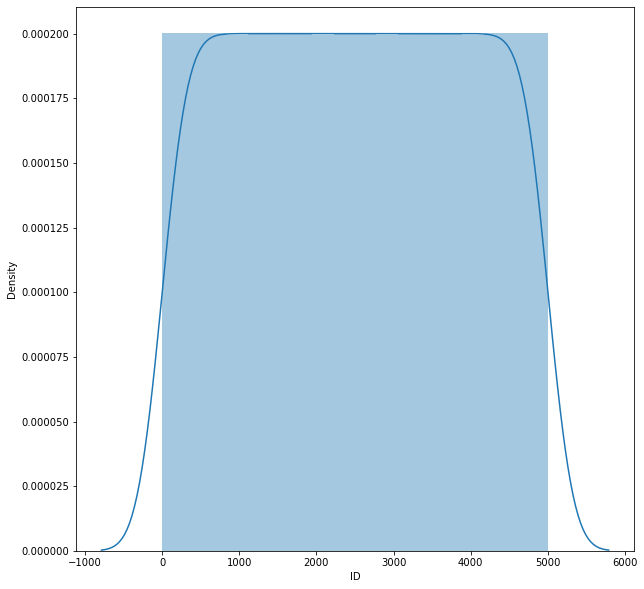

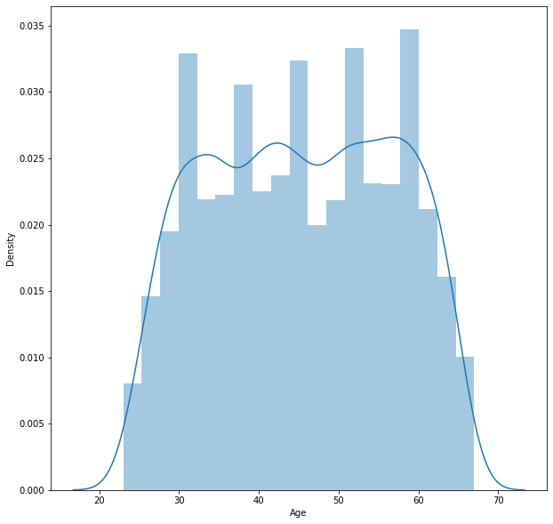

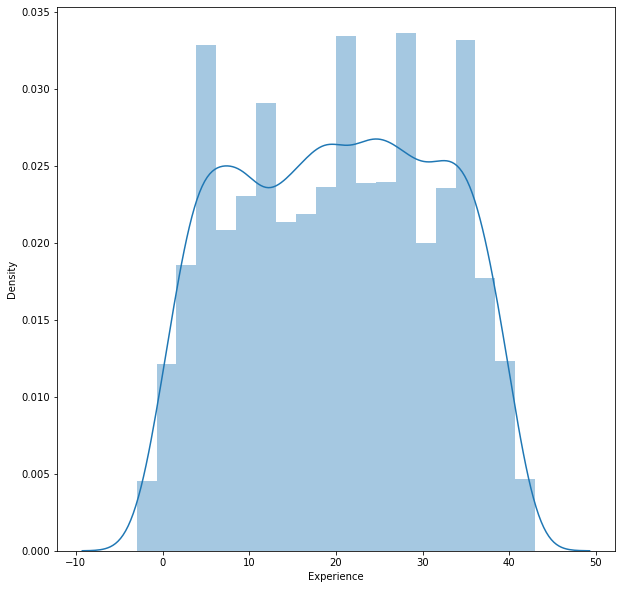

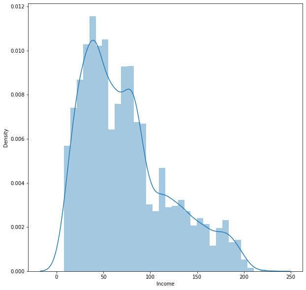

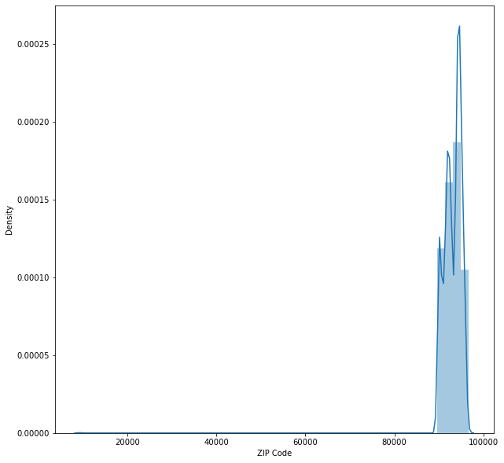

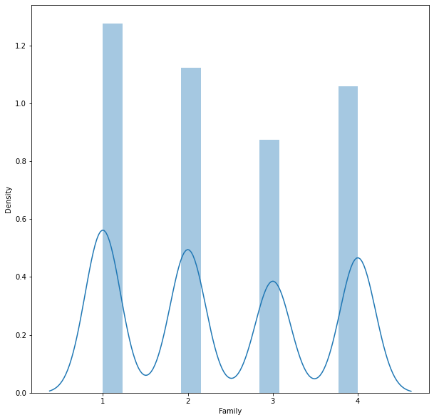

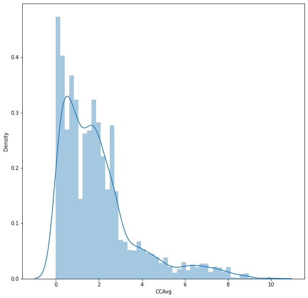

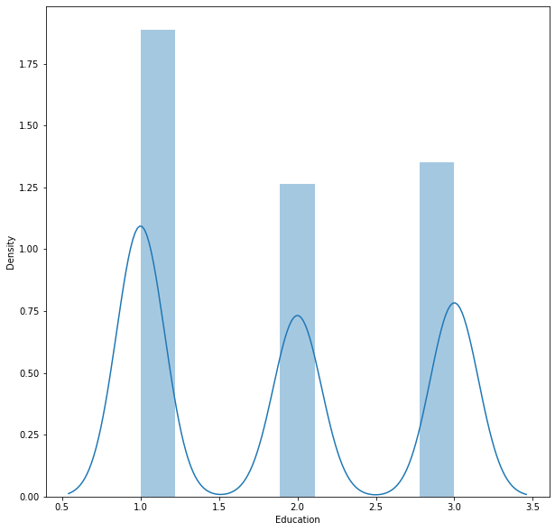

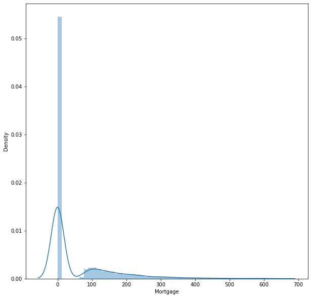

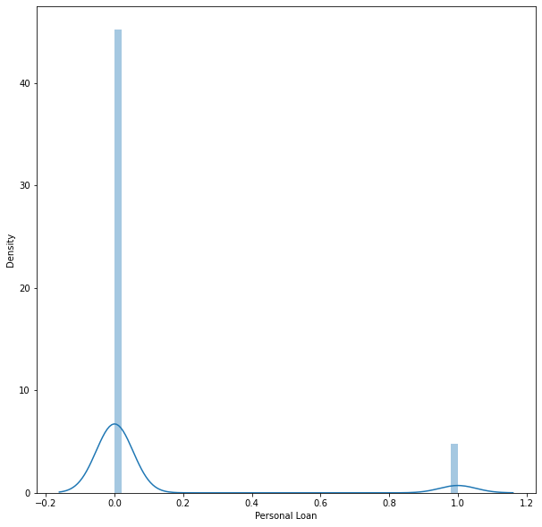

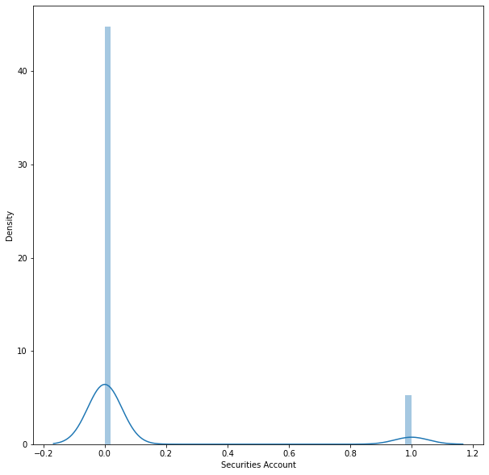

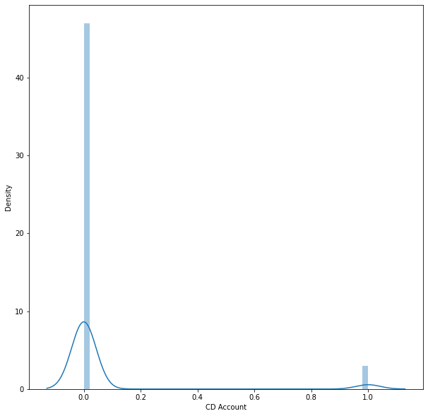

[2 more figures not shown]

```python
#Distribution of all the columns and also assess the skewness
for i in df.columns:
    plt.figure(figsize = (10,10))
    sns.distplot(df[i])
    plt.show()
```

### Insights and Summary from Univariate Analysis

For the Univariate analysis and based on items computed so far, AND THE GIVEN DATA SET sample, we summarize our insights as follows:

- There were no null values or missing values as a result of the null check
- The datatypes for all columns were numerical and no objects or strings were observed. However some of the columns were observed to be binary 1 or 0 which implies these were mapped as ordinals from Yes/No type categorical data.
- From the description of the dataset using the describe() and the histogram plots above we describe the distribution of the columns and skewness as follwos:

Age:The data distribution is uniform with mean and median very close in values

Experience:The data distribution is uniform and has similar characteristics as the Age attribute.

Income: The data distribution is right skewed with mean greater than median

ZIP Code: the data distribution is slightly left skewed but with relatively narrow range and standard deviation

Mortgage: A majority of customers do not have mortgage with the Bank.

Securities Account : Approximately 89.56% did not have a securities account wih the bank

CD account: Approximately 93.96% did not have a CD account with the bank.

Online: slightly higher number of customers use online banking in the sample.

Credit Card: More than twice the number of customers do not use credit card issued by the bank compared to those that use the credit card issued by the bank

### Bivariate Analysis

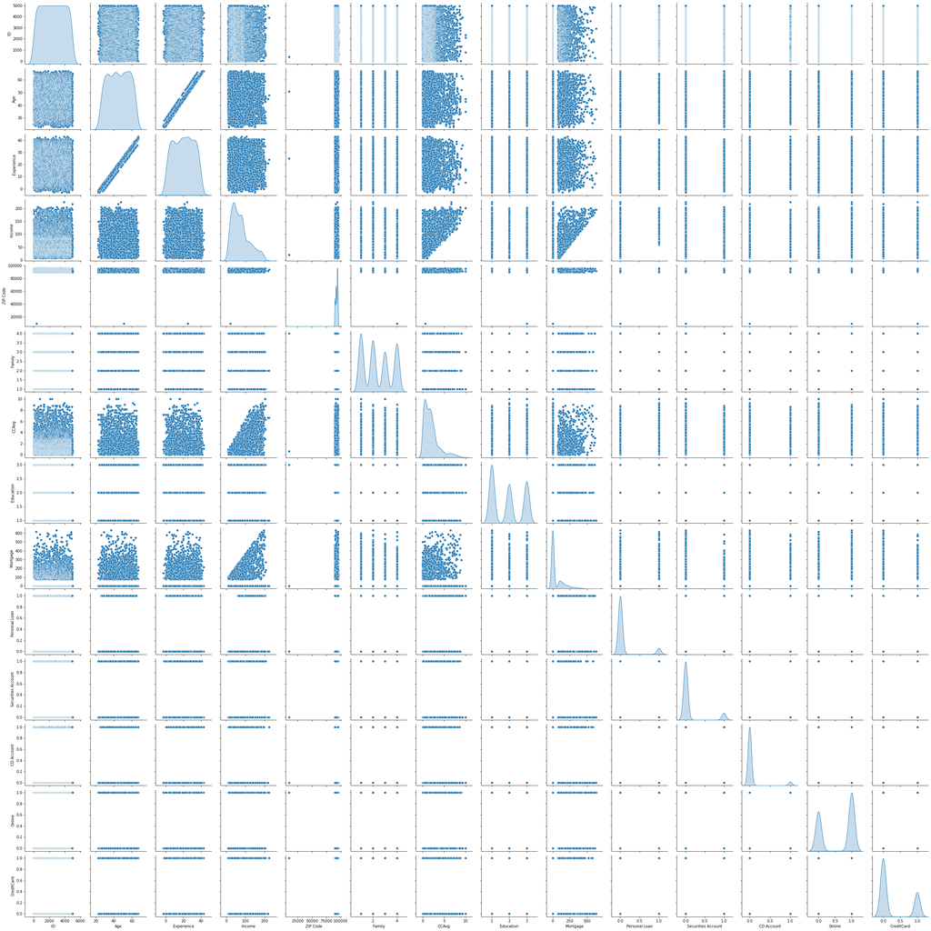

```python
df_v2 = df
sns.pairplot(data =df_v2,diag_kind ='kde')
```

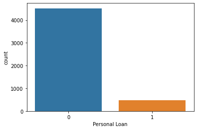

```python
sns.countplot(df["Personal Loan"])
```

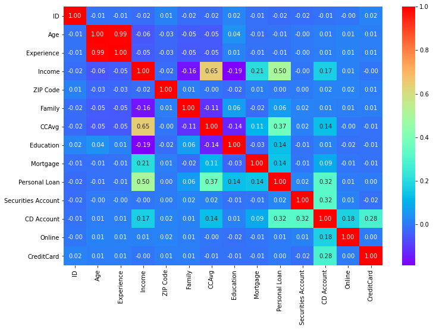

```python
plt.figure(figsize=(12,8))
sns.heatmap(df.corr(),annot=True,fmt='.2f',cmap='rainbow', )
plt.show()
```

```python
#show the relationship between the target and each attribute
df.groupby(df['Personal Loan']).mean()
```

| Personal Loan | ID | Age | Experience | Income | ZIP Code | Family | CCAvg | Education | Mortgage | Securities Account | CD Account | Online | CreditCard |
| --- | --- | --- | --- | --- | --- | --- | --- | --- | --- | --- | --- | --- | --- |
| 0 | 2512.165487 | 45.367257 | 20.132301 | 66.237389 | 93152.428761 | 2.373451 | 1.729009 | 1.843584 | 51.789381 | 0.102212 | 0.035841 | 0.595796 | 0.293584 |
| 1 | 2390.650000 | 45.066667 | 19.843750 | 144.745833 | 93153.202083 | 2.612500 | 3.905354 | 2.233333 | 100.845833 | 0.125000 | 0.291667 | 0.606250 | 0.297917 |

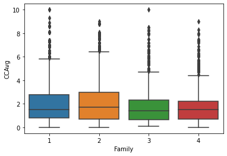

```python
var = 'Family'
data = pd.concat([df['CCAvg'], df[var]], axis =1)
data.head()
#f, ax = plt.subplots(figsize=(14,8))
sns.boxplot(x=var,y="CCAvg", data = data)
#fig.axis(ymin=300000, ymax= 2000000);
```

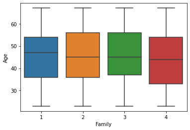

```python
var = 'Family'
data = pd.concat([df['Age'], df[var]], axis =1)
data.head()
#f, ax = plt.subplots(figsize=(14,8))
sns.boxplot(x=var,y="Age", data = data)
#fig.axis(ymin=300000, ymax= 2000000);
```

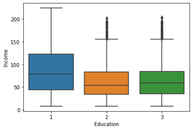

```python
var = 'Education'
data = pd.concat([df['Income'], df[var]], axis =1)
data.head()
#f, ax = plt.subplots(figsize=(14,8))
sns.boxplot(x=var,y="Income", data = data)
#fig.axis(ymin=300000, ymax= 2000000);
```

```python
df4 = df
df4.rename(columns={'Personal Loan':'PL'}, inplace=True)
pd.crosstab(df4.PL, df4.Age, margins=True)
```

| Age PL | 23 | 24 | 25 | 26 | 27 | 28 | 29 | 30 | 31 | 32 | ... | 59 | 60 | 61 | 62 | 63 | 64 | 65 | 66 | 67 | All |
| --- | --- | --- | --- | --- | --- | --- | --- | --- | --- | --- | --- | --- | --- | --- | --- | --- | --- | --- | --- | --- | --- |
| 0 | 12 | 28 | 53 | 65 | 79 | 94 | 108 | 119 | 118 | 108 | ... | 123 | 117 | 110 | 114 | 92 | 70 | 66 | 24 | 12 | 4520 |
| 1 | 0 | 0 | 0 | 13 | 12 | 9 | 15 | 17 | 7 | 12 | ... | 9 | 10 | 12 | 9 | 16 | 8 | 14 | 0 | 0 | 480 |
| All | 12 | 28 | 53 | 78 | 91 | 103 | 123 | 136 | 125 | 120 | ... | 132 | 127 | 122 | 123 | 108 | 78 | 80 | 24 | 12 | 5000 |

3 rows × 46 columns

```python
pd.crosstab(df4.PL, df4.Education, margins=True)
```

| Education PL | 1 | 2 | 3 | All |
| --- | --- | --- | --- | --- |
| 0 | 2003 | 1221 | 1296 | 4520 |
| 1 | 93 | 182 | 205 | 480 |
| All | 2096 | 1403 | 1501 | 5000 |

```python
pd.crosstab(df4.PL, df4.Income, margins=True)
```

| Income PL | 8 | 9 | 10 | 11 | 12 | 13 | 14 | 15 | 18 | 19 | ... | 199 | 200 | 201 | 202 | 203 | 204 | 205 | 218 | 224 | All |
| --- | --- | --- | --- | --- | --- | --- | --- | --- | --- | --- | --- | --- | --- | --- | --- | --- | --- | --- | --- | --- | --- |
| 0 | 23 | 26 | 23 | 27 | 30 | 32 | 31 | 33 | 53 | 52 | ... | 3 | 3 | 4 | 1 | 1 | 3 | 2 | 1 | 1 | 4520 |
| 1 | 0 | 0 | 0 | 0 | 0 | 0 | 0 | 0 | 0 | 0 | ... | 0 | 0 | 1 | 1 | 1 | 0 | 0 | 0 | 0 | 480 |
| All | 23 | 26 | 23 | 27 | 30 | 32 | 31 | 33 | 53 | 52 | ... | 3 | 3 | 5 | 2 | 2 | 3 | 2 | 1 | 1 | 5000 |

3 rows × 163 columns

```python
pd.crosstab(df4.PL, df4.CCAvg, margins=True)
```

| CCAvg PL | 0.0 | 0.1 | 0.2 | 0.3 | 0.4 | 0.5 | 0.6 | 0.67 | 0.7 | 0.75 | ... | 8.2 | 8.3 | 8.5 | 8.6 | 8.8 | 8.9 | 9.0 | 9.3 | 10.0 | All |
| --- | --- | --- | --- | --- | --- | --- | --- | --- | --- | --- | --- | --- | --- | --- | --- | --- | --- | --- | --- | --- | --- |
| 0 | 105 | 181 | 196 | 235 | 175 | 155 | 114 | 18 | 163 | 9 | ... | 0 | 0 | 0 | 8 | 8 | 0 | 0 | 0 | 0 | 4520 |
| 1 | 1 | 2 | 8 | 6 | 4 | 8 | 4 | 0 | 6 | 0 | ... | 1 | 2 | 2 | 0 | 1 | 1 | 2 | 1 | 3 | 480 |
| All | 106 | 183 | 204 | 241 | 179 | 163 | 118 | 18 | 169 | 9 | ... | 1 | 2 | 2 | 8 | 9 | 1 | 2 | 1 | 3 | 5000 |

3 rows × 109 columns

### Insights and Summary from Bivariate Analysis

### For the Bivariate analysis and based on items computed so far, AND THE GIVEN DATA SET sample, we summarize our insights as follows:

- Attributes Age and Experience have similar data distribution and with correlation approximately 1. Therefore one of them can be dropped.
- From the corr and heatmap it can be observed that Income, CCAvg and CDAccount are significant attributes that impact personal Loan

### Get Data Model ready

#### In getting the data model ready we shall consider the following

- drop appropriate columns and give reasons why
- address the negative value(s) observed in column Experience
- apply one-hot encoding where applicable
- configure such that the Personal Loan column becomes the target variable and the remaining columns the independent variables

```python
# back up the dataframe
df.rename(columns={'PL':'Personal Loan'}, inplace=True)

df_v2 = df
df_v2.head()
```

|  | ID | Age | Experience | Income | ZIP Code | Family | CCAvg | Education | Mortgage | Personal Loan | Securities Account | CD Account | Online | CreditCard |
| --- | --- | --- | --- | --- | --- | --- | --- | --- | --- | --- | --- | --- | --- | --- |
| 0 | 1 | 25 | 1 | 49 | 91107 | 4 | 1.6 | 1 | 0 | 0 | 1 | 0 | 0 | 0 |
| 1 | 2 | 45 | 19 | 34 | 90089 | 3 | 1.5 | 1 | 0 | 0 | 1 | 0 | 0 | 0 |
| 2 | 3 | 39 | 15 | 11 | 94720 | 1 | 1.0 | 1 | 0 | 0 | 0 | 0 | 0 | 0 |
| 3 | 4 | 35 | 9 | 100 | 94112 | 1 | 2.7 | 2 | 0 | 0 | 0 | 0 | 0 | 0 |
| 4 | 5 | 35 | 8 | 45 | 91330 | 4 | 1.0 | 2 | 0 | 0 | 0 | 0 | 0 | 1 |

```python
#determine the negative values in atribute Experience
df_v2['Experience'].value_counts()
```

```
 32    154
 20    148
 9     147
 5     146
 23    144
 35    143
 25    142
 28    138
 18    137
 19    135
 26    134
 24    131
 3     129
 14    127
 16    127
```

[output cut: 33 more lines]

```python
df['Experience'].replace( to_replace= -1,value = np.nan,inplace = True )
df['Experience'].replace( to_replace= -2,value = np.nan,inplace = True )
df['Experience'].replace( to_replace= -3,value = np.nan,inplace = True )
```

```python
df_v2['Experience'].isnull().sum()
```

```
52
```

```python
# replace with median
df_v2['Experience'].fillna(df['Experience'].median(),inplace=True)
```

```python
#We however decided to drop attribute Experience but keep attribute Age. The reason is that both attributes are similar
# and keeping both does not provide any additional or useful information.
df_v2.drop(columns ='Experience',inplace= True)
df_v2.head()
```

|  | ID | Age | Income | ZIP Code | Family | CCAvg | Education | Mortgage | Personal Loan | Securities Account | CD Account | Online | CreditCard |
| --- | --- | --- | --- | --- | --- | --- | --- | --- | --- | --- | --- | --- | --- |
| 0 | 1 | 25 | 49 | 91107 | 4 | 1.6 | 1 | 0 | 0 | 1 | 0 | 0 | 0 |
| 1 | 2 | 45 | 34 | 90089 | 3 | 1.5 | 1 | 0 | 0 | 1 | 0 | 0 | 0 |
| 2 | 3 | 39 | 11 | 94720 | 1 | 1.0 | 1 | 0 | 0 | 0 | 0 | 0 | 0 |
| 3 | 4 | 35 | 100 | 94112 | 1 | 2.7 | 2 | 0 | 0 | 0 | 0 | 0 | 0 |
| 4 | 5 | 35 | 45 | 91330 | 4 | 1.0 | 2 | 0 | 0 | 0 | 0 | 0 | 1 |

```python
df_v2.drop(columns ='ID',inplace=True)

#ID does not appear to add value since there is a unique ID per person
```

```python
#one-hot encoding for Education
df_v2['Education_CAT'] = 'none'
df_v2.head()
```

|  | Age | Income | ZIP Code | Family | CCAvg | Education | Mortgage | Personal Loan | Securities Account | CD Account | Online | CreditCard | Education_CAT |
| --- | --- | --- | --- | --- | --- | --- | --- | --- | --- | --- | --- | --- | --- |
| 0 | 25 | 49 | 91107 | 4 | 1.6 | 1 | 0 | 0 | 1 | 0 | 0 | 0 | none |
| 1 | 45 | 34 | 90089 | 3 | 1.5 | 1 | 0 | 0 | 1 | 0 | 0 | 0 | none |
| 2 | 39 | 11 | 94720 | 1 | 1.0 | 1 | 0 | 0 | 0 | 0 | 0 | 0 | none |
| 3 | 35 | 100 | 94112 | 1 | 2.7 | 2 | 0 | 0 | 0 | 0 | 0 | 0 | none |
| 4 | 35 | 45 | 91330 | 4 | 1.0 | 2 | 0 | 0 | 0 | 0 | 0 | 1 | none |

```python
#create a dictionary that describes the mapping for education categories as given in the dataset description
cat_mapping = {
    1: "Undergrad",
    2: "Graduate",
    3: "Advanced/Professional"
}
```

```python
#apply mapping
df_v2['Education_CAT']= df_v2['Education'].map(cat_mapping)
df_v2.head()
```

|  | Age | Income | ZIP Code | Family | CCAvg | Education | Mortgage | Personal Loan | Securities Account | CD Account | Online | CreditCard | Education_CAT |
| --- | --- | --- | --- | --- | --- | --- | --- | --- | --- | --- | --- | --- | --- |
| 0 | 25 | 49 | 91107 | 4 | 1.6 | 1 | 0 | 0 | 1 | 0 | 0 | 0 | Undergrad |
| 1 | 45 | 34 | 90089 | 3 | 1.5 | 1 | 0 | 0 | 1 | 0 | 0 | 0 | Undergrad |
| 2 | 39 | 11 | 94720 | 1 | 1.0 | 1 | 0 | 0 | 0 | 0 | 0 | 0 | Undergrad |
| 3 | 35 | 100 | 94112 | 1 | 2.7 | 2 | 0 | 0 | 0 | 0 | 0 | 0 | Graduate |
| 4 | 35 | 45 | 91330 | 4 | 1.0 | 2 | 0 | 0 | 0 | 0 | 0 | 1 | Graduate |

```python
df_v2_OHE = pd.get_dummies(df_v2['Education_CAT'])
df_v2_OHE.head()
```

|  | Advanced/Professional | Graduate | Undergrad |
| --- | --- | --- | --- |
| 0 | 0 | 0 | 1 |
| 1 | 0 | 0 | 1 |
| 2 | 0 | 0 | 1 |
| 3 | 0 | 1 | 0 |
| 4 | 0 | 1 | 0 |

```python
df_clean = pd.concat([df_v2, df_v2_OHE], axis = 1)
df_clean.head()
```

|  | Age | Income | ZIP Code | Family | CCAvg | Education | Mortgage | Personal Loan | Securities Account | CD Account | Online | CreditCard | Education_CAT | Advanced/Professional | Graduate | Undergrad |
| --- | --- | --- | --- | --- | --- | --- | --- | --- | --- | --- | --- | --- | --- | --- | --- | --- |
| 0 | 25 | 49 | 91107 | 4 | 1.6 | 1 | 0 | 0 | 1 | 0 | 0 | 0 | Undergrad | 0 | 0 | 1 |
| 1 | 45 | 34 | 90089 | 3 | 1.5 | 1 | 0 | 0 | 1 | 0 | 0 | 0 | Undergrad | 0 | 0 | 1 |
| 2 | 39 | 11 | 94720 | 1 | 1.0 | 1 | 0 | 0 | 0 | 0 | 0 | 0 | Undergrad | 0 | 0 | 1 |
| 3 | 35 | 100 | 94112 | 1 | 2.7 | 2 | 0 | 0 | 0 | 0 | 0 | 0 | Graduate | 0 | 1 | 0 |
| 4 | 35 | 45 | 91330 | 4 | 1.0 | 2 | 0 | 0 | 0 | 0 | 0 | 1 | Graduate | 0 | 1 | 0 |

```python
df_clean.drop(columns ='Education',inplace= True)
df_clean.drop(columns ='Education_CAT',inplace= True)
df_clean.head()
```

|  | Age | Income | ZIP Code | Family | CCAvg | Mortgage | Personal Loan | Securities Account | CD Account | Online | CreditCard | Advanced/Professional | Graduate | Undergrad |
| --- | --- | --- | --- | --- | --- | --- | --- | --- | --- | --- | --- | --- | --- | --- |
| 0 | 25 | 49 | 91107 | 4 | 1.6 | 0 | 0 | 1 | 0 | 0 | 0 | 0 | 0 | 1 |
| 1 | 45 | 34 | 90089 | 3 | 1.5 | 0 | 0 | 1 | 0 | 0 | 0 | 0 | 0 | 1 |
| 2 | 39 | 11 | 94720 | 1 | 1.0 | 0 | 0 | 0 | 0 | 0 | 0 | 0 | 0 | 1 |
| 3 | 35 | 100 | 94112 | 1 | 2.7 | 0 | 0 | 0 | 0 | 0 | 0 | 0 | 1 | 0 |
| 4 | 35 | 45 | 91330 | 4 | 1.0 | 0 | 0 | 0 | 0 | 0 | 1 | 0 | 1 | 0 |

```python
#separating dependent and independent variables
Y = df_clean['Personal Loan']
X = df_clean.drop(columns = {'Personal Loan'})
```

### Question 3: Split the data into training and test set in the ratio of 70:30 respectively (5 marks)

```python
#splitting the data in 70:30 ratio of train to test data
X_train, X_test, y_train, y_test = train_test_split(X, Y, test_size=0.30 , random_state=1)
```

### Question 4: Use the Logistic Regression model to predict whether the customer will take a personal loan or not. Print all the metrics related to evaluating the model performance (accuracy, recall, precision, f1score, and roc_auc_score). Draw a heatmap to display confusion matrix (15 marks)

```python
#intialise and fit  model to the train data
regression_model = LogisticRegression(random_state=7)
regression_model.fit(X_train, y_train)
```

```
LogisticRegression(C=1.0, class_weight=None, dual=False, fit_intercept=True,
                   intercept_scaling=1, l1_ratio=None, max_iter=100,
                   multi_class='auto', n_jobs=None, penalty='l2',
                   random_state=7, solver='lbfgs', tol=0.0001, verbose=0,
                   warm_start=False)
```

```python
y_predicted =  regression_model.predict(X_test)
y_predicted
```

```
array([0, 0, 0, ..., 0, 0, 0], dtype=int64)
```

```python
print('Accuracy of logistic regression classifier on train set: {:.2f}'.format(regression_model.score(X_train, y_train)))
```

```
Accuracy of logistic regression classifier on train set: 0.91
```

```python
y_pred = regression_model.predict(X_test)
```

```python
print('Accuracy of logistic regression classifier on test set: {:.2f}'.format(regression_model.score(X_test, y_test)))
```

```
Accuracy of logistic regression classifier on test set: 0.91
```

```python
from sklearn.metrics import confusion_matrix,accuracy_score
```

### Print all the metrics related to evaluating the model performance (accuracy, recall, precision, f1score, and roc_auc_score).

```python
print(classification_report(y_test, y_pred))
```

```
              precision    recall  f1-score   support

           0       0.93      0.98      0.95      1351
           1       0.57      0.30      0.39       149

    accuracy                           0.91      1500
   macro avg       0.75      0.64      0.67      1500
weighted avg       0.89      0.91      0.89      1500
```

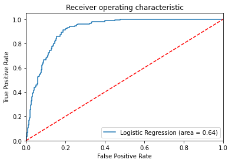

```python
from sklearn.metrics import roc_auc_score
from sklearn.metrics import roc_curve
logit_roc_auc = roc_auc_score(y_test, regression_model.predict(X_test))
fpr, tpr, thresholds = roc_curve(y_test, regression_model.predict_proba(X_test)[:,1])
plt.figure()
plt.plot(fpr, tpr, label='Logistic Regression (area = %0.2f)' % logit_roc_auc)
plt.plot([0, 1], [0, 1],'r--')
plt.xlim([0.0, 1.0])
plt.ylim([0.0, 1.05])
plt.xlabel('False Positive Rate')
plt.ylabel('True Positive Rate')
plt.title('Receiver operating characteristic')
plt.legend(loc="lower right")
plt.savefig('Log_ROC')
plt.show()
```

### Draw a heatmap to display confusion matrix

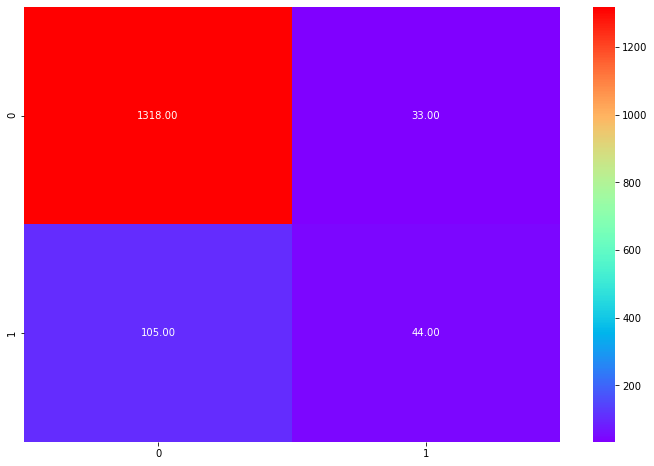

```python
confusion_matrix = confusion_matrix(y_test, y_pred)
plt.figure(figsize=(12,8))
sns.heatmap(confusion_matrix,annot=True,fmt='.2f',cmap='rainbow' )
plt.show()
```

### Question 5: Find out coefficients of all the attributes and show the output in a data frame with column names? For test data show all the rows where the predicted class is not equal to the observed class. (10 marks)

```python
# print out the coeficients
print(regression_model.coef_, regression_model.intercept_)
```

```
[[-4.54698994e-04  3.63106687e-02 -6.55756183e-05  1.72061304e-04
   1.10772683e-03  8.51181704e-04  9.40536217e-06  1.40672764e-04
   1.21752789e-05  5.11799998e-06  7.72351427e-05  7.41499571e-05
  -1.52552619e-04]] [-1.16751967e-06]
```

```python
# Find out coefficients of all the attributes and show the output in a data frame with column names?
cdf = pd.DataFrame(regression_model.coef_.T, X.columns, columns=['Coefficients'])
print(cdf)
```

```
                       Coefficients
Age                       -0.000455
Income                     0.036311
ZIP Code                  -0.000066
Family                     0.000172
CCAvg                      0.001108
Mortgage                   0.000851
Securities Account         0.000009
CD Account                 0.000141
Online                     0.000012
CreditCard                 0.000005
Advanced/Professional      0.000077
Graduate                   0.000074
Undergrad                 -0.000153
```

```python
from sklearn.metrics import confusion_matrix,accuracy_score
```

```python
# creating a new dataframe
z = pd.DataFrame()

# Storing actual output of target variable
z['Actual'] = y_test.values

z['Probaility that output is 0'] = regression_model.predict_proba(X_test)[:,0]
# Probabilities predicted by Logistic regression model
z['Probaility that output is 1'] = regression_model.predict_proba(X_test)[:,1]

 # Predicting target variable using sklearn Logistic regression
z['Predicted'] = regression_model.predict(X_test)

#Number of people with zero credit card spending per month?
print(z[z.Actual != z.Predicted])


# In sklearn default threshold is 0.5
# therfore for all the values whose probability for 1 is greater than 0.5 will be predicted as 1
```

```
      Actual  Probaility that output is 0  Probaility that output is 1  \
40         0                     0.335385                     0.664615
44         1                     0.692729                     0.307271
48         1                     0.949082                     0.050918
51         1                     0.928398                     0.071602
94         1                     0.979011                     0.020989
...      ...                          ...                          ...
1436       0                     0.318003                     0.681997
1437       1                     0.604159                     0.395841
1454       1                     0.868482                     0.131518
1479       1                     0.581412                     0.418588
1481       1                     0.705013                     0.294987

      Predicted
40            1
44            0
48            0
51            0
94            0
...         ...
1436          1
1437          0
1454          0
1479          0
1481          0

[138 rows x 4 columns]
```

```python
def draw_cm( actual, predicted ):
    cm = confusion_matrix( actual, predicted)
    sns.heatmap(cm, annot=True,  fmt='.2f', xticklabels = ["No Loan", "Loan"] , yticklabels = ["No Loan", "Loan"] )
    plt.ylabel('True label')
    plt.xlabel('Predicted label')
    plt.show()
```

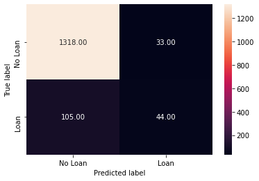

```python
#confusion_matrix = confusion_matrix(y_test, y_pred)
#print(confusion_matrix)
draw_cm( z['Actual'], z['Predicted'] )
```

```python
# code taken from Class Practice Exercise  (with permission)
#Fit logistic regression model  (Statsmodel)
import statsmodels.api as sm

logit = sm.Logit( y_train, sm.add_constant( X_train ) )

lg = logit.fit()

lg.summary2()
```

```
Optimization terminated successfully.
         Current function value: 0.114088
         Iterations 9
```

| Model: | Logit | Pseudo R-squared: | 0.635 |
| --- | --- | --- | --- |
| Dependent Variable: | Personal Loan | AIC: | 824.6183 |
| Date: | 2020-10-09 23:04 | BIC: | 904.7050 |
| No. Observations: | 3500 | Log-Likelihood: | -399.31 |
| Df Model: | 12 | LL-Null: | -1095.5 |
| Df Residuals: | 3487 | LLR p-value: | 6.3490e-291 |
| Converged: | 1.0000 | Scale: | 1.0000 |
| No. Iterations: | 9.0000 |  |  |

|  | Coef. | Std.Err. | z | P>\|z\| | [0.025 | 0.975] |
| --- | --- | --- | --- | --- | --- | --- |
| const | -7.1982 | 6661420.3915 | -0.0000 | 1.0000 | -13056151.2514 | 13056136.8550 |
| Age | 0.0052 | 0.0082 | 0.6327 | 0.5269 | -0.0108 | 0.0212 |
| Income | 0.0589 | 0.0036 | 16.5143 | 0.0000 | 0.0519 | 0.0659 |
| ZIP Code | -0.0000 | 0.0001 | -0.2467 | 0.8052 | -0.0001 | 0.0001 |
| Family | 0.6494 | 0.0960 | 6.7659 | 0.0000 | 0.4613 | 0.8375 |
| CCAvg | 0.2114 | 0.0538 | 3.9268 | 0.0001 | 0.1059 | 0.3170 |
| Mortgage | 0.0010 | 0.0007 | 1.4019 | 0.1609 | -0.0004 | 0.0024 |
| Securities Account | -1.1590 | 0.3997 | -2.8998 | 0.0037 | -1.9424 | -0.3756 |
| CD Account | 3.8450 | 0.4261 | 9.0230 | 0.0000 | 3.0098 | 4.6802 |
| Online | -0.6631 | 0.2002 | -3.3119 | 0.0009 | -1.0555 | -0.2707 |
| CreditCard | -1.0653 | 0.2597 | -4.1021 | 0.0000 | -1.5744 | -0.5563 |
| Advanced/Professional | -1.0114 | 6661420.3915 | -0.0000 | 1.0000 | -13056145.0646 | 13056143.0419 |
| Graduate | -1.1389 | 6661420.3915 | -0.0000 | 1.0000 | -13056145.1921 | 13056142.9143 |
| Undergrad | -5.0479 | 6661420.3915 | -0.0000 | 1.0000 | -13056149.1012 | 13056139.0053 |

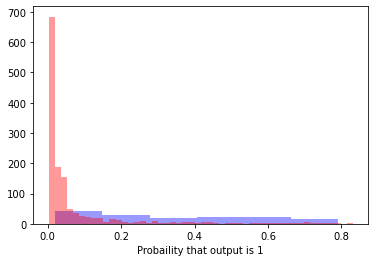

```python
#Predicted Probability distribution Plots for No Loan and Loan
sns.distplot( z[z['Actual'] == 1]["Probaility that output is 1"], kde=False, color = 'b' )
sns.distplot( z[z['Actual'] == 0]["Probaility that output is 1"], kde=False, color = 'r' )
plt.show()
```

### Question 6. Give conclusion related to the Business understanding of your model? (5 marks)

### Investigating effect of change in Threshold

```python
from sklearn.metrics import accuracy_score, confusion_matrix, recall_score, roc_auc_score, precision_score

clf = LogisticRegression(class_weight="balanced")
clf.fit(X_train, y_train)
THRESHOLD = 0.25
preds = np.where(clf.predict_proba(X_test)[:,1] > THRESHOLD, 1, 0)

pd.DataFrame(data=[accuracy_score(y_test, preds), recall_score(y_test, preds),
                   precision_score(y_test, preds), roc_auc_score(y_test, preds)],
             index=["accuracy", "recall", "precision", "roc_auc_score"])
```

|  | 0 |
| --- | --- |
| accuracy | 0.759333 |
| recall | 0.959732 |
| precision | 0.287149 |
| roc_auc_score | 0.848482 |

```python
clf = LogisticRegression(class_weight="balanced")
clf.fit(X_train, y_train)
THRESHOLD = 0.65
preds = np.where(clf.predict_proba(X_test)[:,1] > THRESHOLD, 1, 0)

pd.DataFrame(data=[accuracy_score(y_test, preds), recall_score(y_test, preds),
                   precision_score(y_test, preds), roc_auc_score(y_test, preds)],
             index=["accuracy", "recall", "precision", "roc_auc_score"])
```

|  | 0 |
| --- | --- |
| accuracy | 0.866667 |
| recall | 0.731544 |
| precision | 0.405204 |
| roc_auc_score | 0.806556 |

In our classifier we have taken the positive class i.e class of interest, which is the acceptance of the personal loan from the bank. For our classifier the confusion matrix enables us to compare the predicted labels from the actual or True labels. With the classifier default threshold of 0.5, the confusion matrix gave the True Positives (TP), False Positives (FP) True Negatives (TN) and False Negatives (FN). The TP = 44, FP = 33, TN = 1318, and FN = 105. We also evaluated the following metrics: Accuracy, Recall, Precision, F1 score, and ROC curve including the area under the ROC curve (a_ROC).

The features we found most important to our classifier were: Income and CCAvg.

## Results vs Business Problem

```python
- In this project, the case was  about Thera Bank whose management wanted to explore ways of converting its liability customers to personal loan customers (while retaining them as depositors).
- A campaign that the bank ran last year for liability customers showed a healthy conversion rate of over 9% success.
- This has encouraged the retail marketing department to devise campaigns with better target marketing to increase the success ratio with a minimal budget.

-In summary, the results suggests that our model is a reasonable fit  to the business problem. The model enabled a good
---- prediction, with good accuracy and performance metrics such as Recall and Precision) for the negative class, customers that do not wish to take a personal loan with the bank.
---- this in turn can enable us, by default, to have a good understanding of the positive class.
- Our modeling also showed that Income and Cfg were good features to use for targeting customers.
The zip code data was quite narrow and suggests that the marketing campaign could explore a wider zip code areas.
```